# **importing libraries**

```python
import pandas as pd
import numpy as np
import seaborn as sns
import matplotlib.pyplot as plt
```

# **investigate file**

```python
movies=pd.read_csv('tmdb-movies.csv')
```

function

```python
def scatter(x, y, data="tmdb-movies.csv"):
  plt.title(f"relation between {x} & {y}")
  sns.scatterplot(x=x ,y=y ,data=movies)
  plt.xlabel(x)
  plt.ylabel(y)
  plt.show()
```

function to make it easier to draw a scatter plot

# `1. Is the number of films increasing with the progress of the world?`

# `2. Does production have anything to do with the film’s profit?`

# **Data Assess**

**SHOW THE FIRST 5 ROWS**

```python
movies.head()
```

|  | id | imdb_id | popularity | budget | revenue | original_title | cast | homepage | director | tagline | ... | overview | runtime | genres | production_companies | release_date | vote_count | vote_average | release_year | budget_adj | revenue_adj |
| --- | --- | --- | --- | --- | --- | --- | --- | --- | --- | --- | --- | --- | --- | --- | --- | --- | --- | --- | --- | --- | --- |
| 0 | 135397 | tt0369610 | 32.985763 | 150000000 | 1513528810 | Jurassic World | Chris Pratt\|Bryce Dallas Howard\|Irrfan Khan\|Vi... | http://www.jurassicworld.com/ | Colin Trevorrow | The park is open. | ... | Twenty-two years after the events of Jurassic ... | 124.0 | Action\|Adventure\|Science Fiction\|Thriller | Universal Studios\|Amblin Entertainment\|Legenda... | 6/9/15 | 5562.0 | 6.5 | 2015.0 | 1.379999e+08 | 1.392446e+09 |
| 1 | 76341 | tt1392190 | 28.419936 | 150000000 | 378436354 | Mad Max: Fury Road | Tom Hardy\|Charlize Theron\|Hugh Keays-Byrne\|Nic... | http://www.madmaxmovie.com/ | George Miller | What a Lovely Day. | ... | An apocalyptic story set in the furthest reach... | 120.0 | Action\|Adventure\|Science Fiction\|Thriller | Village Roadshow Pictures\|Kennedy Miller Produ... | 5/13/15 | 6185.0 | 7.1 | 2015.0 | 1.379999e+08 | 3.481613e+08 |
| 2 | 262500 | tt2908446 | 13.112507 | 110000000 | 295238201 | Insurgent | Shailene Woodley\|Theo James\|Kate Winslet\|Ansel... | http://www.thedivergentseries.movie/#insurgent | Robert Schwentke | One Choice Can Destroy You | ... | Beatrice Prior must confront her inner demons ... | 119.0 | Adventure\|Science Fiction\|Thriller | Summit Entertainment\|Mandeville Films\|Red Wago... | 3/18/15 | 2480.0 | 6.3 | 2015.0 | 1.012000e+08 | 2.716190e+08 |
| 3 | 140607 | tt2488496 | 11.173104 | 200000000 | 2068178225 | Star Wars: The Force Awakens | Harrison Ford\|Mark Hamill\|Carrie Fisher\|Adam D... | http://www.starwars.com/films/star-wars-episod... | J.J. Abrams | Every generation has a story. | ... | Thirty years after defeating the Galactic Empi... | 136.0 | Action\|Adventure\|Science Fiction\|Fantasy | Lucasfilm\|Truenorth Productions\|Bad Robot | 12/15/15 | 5292.0 | 7.5 | 2015.0 | 1.839999e+08 | 1.902723e+09 |
| 4 | 168259 | tt2820852 | 9.335014 | 190000000 | 1506249360 | Furious 7 | Vin Diesel\|Paul Walker\|Jason Statham\|Michelle ... | http://www.furious7.com/ | James Wan | Vengeance Hits Home | ... | Deckard Shaw seeks revenge against Dominic Tor... | 137.0 | Action\|Crime\|Thriller | Universal Pictures\|Original Film\|Media Rights ... | 4/1/15 | 2947.0 | 7.3 | 2015.0 | 1.747999e+08 | 1.385749e+09 |

5 rows × 21 columns

to have an idea about the data

**DEFINE NON-FILLED CELLS IN DATAFRAME & the types of the columns**

```python
movies.info()
```

```
<class 'pandas.core.frame.DataFrame'>
RangeIndex: 6621 entries, 0 to 6620
Data columns (total 21 columns):
 #   Column                Non-Null Count  Dtype
---  ------                --------------  -----
 0   id                    6621 non-null   int64
 1   imdb_id               6613 non-null   object
 2   popularity            6621 non-null   float64
 3   budget                6621 non-null   int64
 4   revenue               6621 non-null   int64
 5   original_title        6621 non-null   object
 6   cast                  6565 non-null   object
 7   homepage              2423 non-null   object
 8   director              6583 non-null   object
 9   tagline               4678 non-null   object
 10  keywords              5465 non-null   object
 11  overview              6616 non-null   object
 12  runtime               6620 non-null   float64
 13  genres                6603 non-null   object
 14  production_companies  5915 non-null   object
 15  release_date          6620 non-null   object
 16  vote_count            6620 non-null   float64
 17  vote_average          6620 non-null   float64
 18  release_year          6620 non-null   float64
 19  budget_adj            6620 non-null   float64
 20  revenue_adj           6620 non-null   float64
dtypes: float64(7), int64(3), object(11)
memory usage: 1.1+ MB
```

we have a lot of null values and there are no problem with types

**SHOW THE FIVE NUMBERS THEORY OF EACH CATEGORY**

```python
movies.describe()
```

|  | id | popularity | budget | revenue | runtime | vote_count | vote_average | release_year | budget_adj | revenue_adj |
| --- | --- | --- | --- | --- | --- | --- | --- | --- | --- | --- |
| count | 6621.000000 | 6621.000000 | 6.621000e+03 | 6.621000e+03 | 6620.000000 | 6620.000000 | 6620.000000 | 6620.000000 | 6.620000e+03 | 6.620000e+03 |
| mean | 97891.244676 | 0.715958 | 1.667473e+07 | 4.418623e+07 | 100.299245 | 263.362840 | 5.920876 | 2008.073414 | 1.792908e+07 | 4.782442e+07 |
| std | 105275.632521 | 1.188130 | 3.480914e+07 | 1.335646e+08 | 34.212608 | 676.881587 | 0.974883 | 6.855713 | 3.643913e+07 | 1.445231e+08 |
| min | 11.000000 | 0.000065 | 0.000000e+00 | 0.000000e+00 | 0.000000 | 10.000000 | 2.000000 | 1977.000000 | 0.000000e+00 | 0.000000e+00 |
| 25% | 14326.000000 | 0.207575 | 0.000000e+00 | 0.000000e+00 | 90.000000 | 17.000000 | 5.300000 | 2005.000000 | 0.000000e+00 | 0.000000e+00 |
| 50% | 48838.000000 | 0.393751 | 0.000000e+00 | 0.000000e+00 | 97.000000 | 42.000000 | 6.000000 | 2010.000000 | 0.000000e+00 | 0.000000e+00 |
| 75% | 165739.000000 | 0.780318 | 1.800000e+07 | 2.138404e+07 | 109.000000 | 181.000000 | 6.600000 | 2013.000000 | 1.938796e+07 | 2.419284e+07 |
| max | 417859.000000 | 32.985763 | 4.250000e+08 | 2.781506e+09 | 900.000000 | 9767.000000 | 9.200000 | 2015.000000 | 4.250000e+08 | 2.827124e+09 |

to show us alot more about the data

define non-values in the data

```python
movies.isnull().sum()
#to know the number of non-filled values
```

|  | 0 |
| --- | --- |
| id | 0 |
| imdb_id | 8 |
| popularity | 0 |
| budget | 0 |
| revenue | 0 |
| original_title | 0 |
| cast | 56 |
| homepage | 4198 |
| director | 38 |
| tagline | 1943 |
| keywords | 1156 |
| overview | 5 |
| runtime | 1 |
| genres | 18 |
| production_companies | 706 |
| release_date | 1 |
| vote_count | 1 |
| vote_average | 1 |
| release_year | 1 |
| budget_adj | 1 |
| revenue_adj | 1 |

**dtype:** int64

we can see here alot of null values in the data so we should remove them

**check duplecated data**

```python
movies.duplicated().sum()
#to know the number of duplecated values
```

```
1
```

we have one duplicated value ,so we should remove it

# **Cleaning phase**

we gonna remove the nun-values in the data

```python
movies=movies.dropna()
#to drop the non-filled values
```

```python
movies.isnull().sum()
#to make sure that every thing went right
```

|  | 0 |
| --- | --- |
| id | 0 |
| imdb_id | 0 |
| popularity | 0 |
| budget | 0 |
| revenue | 0 |
| original_title | 0 |
| cast | 0 |
| homepage | 0 |
| director | 0 |
| tagline | 0 |
| keywords | 0 |
| overview | 0 |
| runtime | 0 |
| genres | 0 |
| production_companies | 0 |
| release_date | 0 |
| vote_count | 0 |
| vote_average | 0 |
| release_year | 0 |
| budget_adj | 0 |
| revenue_adj | 0 |

**dtype:** int64

we removed the non-values

we gonna remove the duplicates in the data

```python
movies=movies.drop_duplicates()
#to drop the duplecated values
```

```python
movies.duplicated().sum()
#to make sure that every thing went right
```

```
0
```

we removed the duplicated value in our data

# Univariate Visualization

we gonna show the relationship between the year of puplish and the number of movies

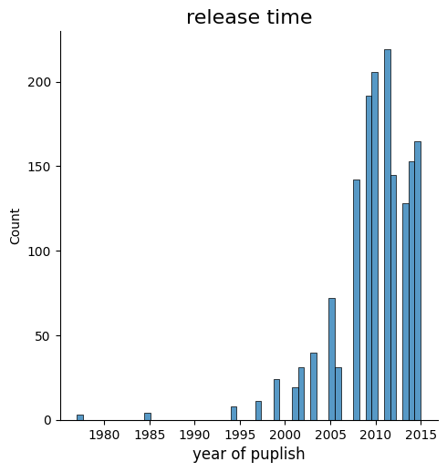

```python
plt.figure(figsize=(10, 6))
sns.displot(x='release_year', data=movies)
#we used distplot as it is suitable in this case
plt.title('release time', fontsize=16)
#to put a title above the statistical summary
plt.xlabel('year of puplish', fontsize=12)
#to put a title under the x axis
plt.show()
```

1. we can see the correlation between releasing date & number of movies
2. it is a positive correlation
3. it is lef skewed data

# Bivariate Visualization with the function

we gonna show the relationship between the budget of the film & its revenue

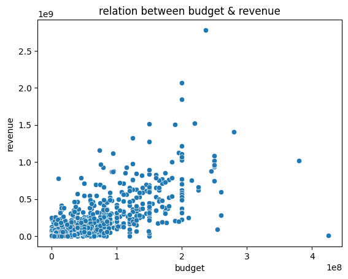

```python
scatter("budget","revenue")
#we used our function
```

we can see that there is a positve correlation between the movie's budget & the revenue

# **coclusion**

1. we can see from our analysis tha there is a positive relation between movie's revenue & the budget
2. we can see that the number of movies is positively related with the year of puplish

## **limitations**

1. we did not have enough time to show our creativity
2. the data set isn't very accurate